# BANA 7050 Spring 2022: Final Project

### 5. Cross-validating for best model parameters

We could choose the most influential aspects within the prophet model by cross-validating upon the training data and assessing statistics like RMSE, MAE, MAPE.

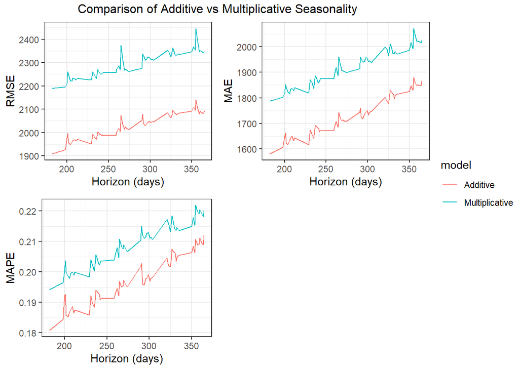

```r
df_cv1 <- cross_validation(additive, initial = 3*365, period = 90, horizon = 365, units = 'days')
metrics1 = performance_metrics(df_cv1, rolling_window = 0.5) %>%
  mutate(model = 'Additive')

df_cv2 <- cross_validation(multi, initial = 3*365, period = 90, horizon = 365, units = 'days')
metrics2 = performance_metrics(df_cv2, rolling_window = 0.5) %>%
  mutate(model = "Multiplicative")


g1=metrics1 %>%
bind_rows(metrics2) %>%
ggplot()+
geom_line(aes(horizon,rmse,color=model))+
  theme_bw()+
  xlab("Horizon (days)")+
  ylab("RMSE")

g2 = metrics1 %>%
bind_rows(metrics2) %>%
ggplot()+
geom_line(aes(horizon,mae,color=model))+
  theme_bw()+
  xlab("Horizon (days)")+
  ylab("MAE")

g3 = metrics1 %>%
bind_rows(metrics2) %>%
ggplot()+
geom_line(aes(horizon,mape,color=model))+
  theme_bw()+
  xlab("Horizon (days)")+
  ylab("MAPE")

grid_arrange_shared_legend(g1, g2, g3, ncol = 2, nrow = 2, position='right', top = "Comparison of Additive vs Multiplicative Seasonality")
```

> As can be noted from the three plots, *Additive seasonality* is most explanatory for this data.

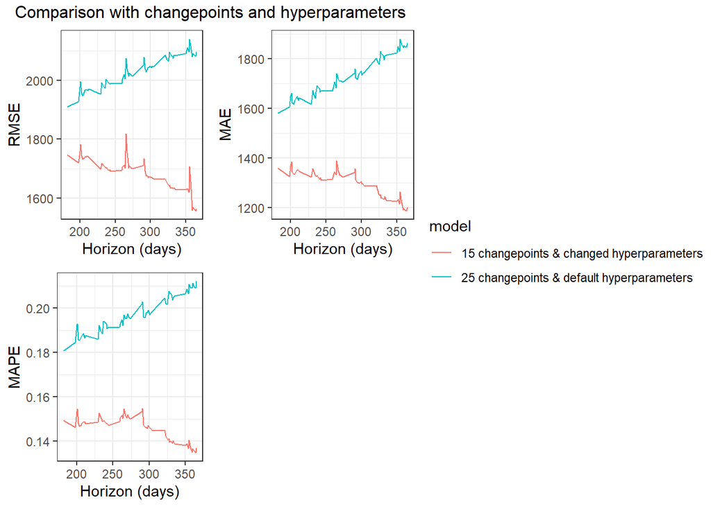

```r
old_changepoint_mod = prophet::prophet(prophet_data)

df_cv5 <- cross_validation(old_changepoint_mod, initial = 3*365, period = 90, horizon = 365, units = 'days')
metrics5 = performance_metrics(df_cv5, rolling_window = 0.5) %>%
  mutate(model = '25 changepoints & default hyperparameters')

new_changepoint_mod = prophet::prophet(prophet_data, n.changepoints = 15, changepoint.prior.scale = 0.09, changepoint.range = 0.7)

df_cv6 <- cross_validation(new_changepoint_mod, initial = 3*365, period = 90, horizon = 365, units = 'days')
metrics6 = performance_metrics(df_cv6, rolling_window = 0.5) %>%
  mutate(model = "15 changepoints & changed hyperparameters")


g7=metrics5 %>%
bind_rows(metrics6) %>%
ggplot()+
geom_line(aes(horizon,rmse,color=model))+
  theme_bw()+
  xlab("Horizon (days)")+
  ylab("RMSE")

g8 = metrics5 %>%
bind_rows(metrics6) %>%
ggplot()+
geom_line(aes(horizon,mae,color=model))+
  theme_bw()+
  xlab("Horizon (days)")+
  ylab("MAE")

g9 = metrics5 %>%
bind_rows(metrics6) %>%
ggplot()+
geom_line(aes(horizon,mape,color=model))+
  theme_bw()+
  xlab("Horizon (days)")+
  ylab("MAPE")

grid_arrange_shared_legend(g7, g8, g9, ncol = 2, nrow = 2, position='right', top = "Comparison with changepoints and hyperparameters")
```

> All three plots suggest that *lower number of changepoints* are better at describing the alterations in the trend.

**Inference**

*best_fit_model = prophet::prophet(prophet_data, n.changepoints = 15, growth = ‘logistic’, seasonality.mode = ‘additive’)*

## Model Comparison and Validation

To assess and compare the performance of the selected ARIMA and Prophet model versus a naive model, it is required to conduct cross-validation on the time series data. From the training data, an initial period of 3 years is used to train the model, and a 6 month period is iterated upon. Finally, a 6 month forecast is conducted using this dataset, in every iteration.

```r
cv_data = data_mod %>%
  stretch_tsibble(.init = 36, .step = 6)
```

```r
cv_forecast = cv_data %>%
  model(snaive = SNAIVE(Freq),
  arima = fable::ARIMA(Freq,approximation=F, stepwise=F)) %>%
  forecast(h = 6)
```

```r
accuracy_forecast<-cv_forecast%>%
  accuracy(data_mod) %>%
  data.table::data.table()%>%
  dplyr::select(.model,RMSE)

knitr::kable(accuracy_forecast)
```

| .model | RMSE |
| --- | --- |
| arima | 2481.244 |
| snaive | 1753.321 |

```r
best_fit_model = prophet::prophet(prophet_data, n.changepoints = 15, growth = 'logistic', seasonality.mode = 'additive')

df.cv <- cross_validation(best_fit_model, initial = 3*365, period = 180, horizon = 365/2, units = 'days')

metrics = performance_metrics(df.cv, rolling_window = 0.3) %>%
  mutate(model = "Best Fit Model")

print(paste("RMSE for Best Fit Prophet Model:", round(mean(metrics$rmse),3)))
```

```
[1] "RMSE for Best Fit Prophet Model: 1850.624"
```

```r
accuracy_tbl <- data.frame(model= c('snaive','arima','prophet'),
                           RMSE = c(accuracy_forecast$RMSE[2],accuracy_forecast$RMSE[1], round(mean(metrics$rmse),3)))

knitr::kable(accuracy_tbl%>%
  arrange(RMSE))
```

| model | RMSE |
| --- | --- |
| snaive | 1753.321 |
| prophet | 1850.624 |
| arima | 2481.244 |

**Inference**

As a result of the cross-validation, it can be seen that the SNAIVE model has the lowest RMSE, implying this is the best model for our time series.

## Forecast

As the SNAIVE model has been deduced as the best model, it can now be run on the test data (i.e. data over 2019/01/01). Further, a 1 year forecast has also been predicted for the year 2023.

```r
test_set<-test %>%
  dplyr::select(REQUESTED_DATE) %>%
  mutate(DateTime = yearmonth(as.yearmon(mdy_hms(REQUESTED_DATE),"%m%Y"))) %>%
  group_by(DateTime) %>%
  summarise(Freq = n()) %>%
  arrange(DateTime) %>%
  as_tsibble(index = DateTime)

data_mod %>%
  model(
  SNAIVE(Freq)) %>%
  forecast(h=60) %>%
  accuracy(test_set)%>%
  data.table::data.table()%>%
  dplyr::select(.model,RMSE, MAE, MAPE)
```

```
         .model     RMSE      MAE     MAPE
1: SNAIVE(Freq) 1737.099 1241.125 17.15181
```

> The SNAIVE model performs with an RMSE of 1737 on the test data.

> A graphical representation of the out-of-sample data and a 1 year forecast for the year 2023 has been created below.

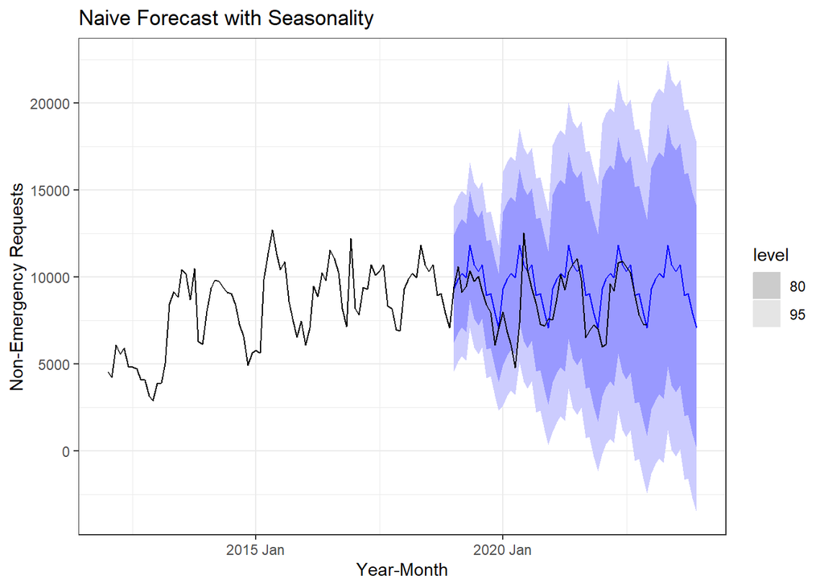

```r
#SNaive Forecast
data_mod %>%
  model(
  SNAIVE(Freq)) %>%
  forecast(h=60) %>%
  autoplot(test_set%>%
             bind_rows(data_mod))+
  theme_bw()+
  labs(title = "Naive Forecast with Seasonality",
       y = "Non-Emergency Requests",
       x = "Year-Month")
```

```r
#scale_x_yearmonth(c("2012 Jan","2014 Jan","2016 Jan", "2018 Jan", "2020 Jan"))
```

**Conclusion**

In year 2023, for the Cincinnati 311 Non-Emergency Service Requests dataset, the frequency of non-emergency requests would be between the range 7500-12500 with a high forecasting error.